Practica 1 DEX Marta Venegas Pardo

Del tema 2.

# Ejemplo 1. Pollos

A cada animal le hemos observado dos cosas, la variable respuesta y los niveles del factor

```r
y<-c(100,115,95,99,105,115,98,97,93,95,98,105,105,110,94) # respuesta
 a<-c(rep(1,5),rep(2,5),rep(3,5)) # niveles del factor
 a<-factor(a) # hay que declararlo como factor, porque si no es una varaible numérica en R, cosa que no es
```

## Contraste

El contraste que vamos a realizar es el siguiente (pag5) apuntes:

$$\left\{
\begin{array}{ll}
H_{0}: & \alpha_1 = \alpha_2 = \alpha_3\\
H_{1}: & \alpha_i \neq \alpha_j \quad \text{para algunos } i\neq j
\end{array}
\right.$$

## Tabla anova

```r
ejemplo1<-aov(y~a) # Análisis de la varianza = aov=(respuesta ~ factor)
 # N=15 , k=3
 summary(ejemplo1) # tabla de la varianza
```

```
##             Df Sum Sq Mean Sq F value Pr(>F)
## a            2   30.4    15.2   0.257  0.777
## Residuals   12  709.2    59.1
```

- k=3
- N=15

Conclusiones:

- Gr lib: k-1 = 2
- Gr lib res_ N-k = 12
- $CM_{a}/CM_{r}$
- *p-valor*: RC=p-valor$ = 0.777 > = 0.05$, luego, no hay evidencias en contra de $H_0$

Es decir, no existen evidencias para decir que las condiciones ambientales consideradas incidan en la ganancia de peso de los pollos.

Si a no es declarado factor, ocurriría un desastre. Haría el modelo lineal $y = \beta_0 + \beta_1 \cdot a + \epsilon$

```r
 a<-c(rep(1,5),rep(2,5),rep(3,5)) # niveles del factor

 ejemplo1.mal<-aov(y~a) # Análisis de la varianza = aov=(respuesta ~ factor)

 summary(ejemplo1.mal) # tabla de la varianza
```

```
##             Df Sum Sq Mean Sq F value Pr(>F)
## a            1    0.4    0.40   0.007  0.934
## Residuals   13  739.2   56.86
```

Ahora estamos contrastando:

$$\left\{
\begin{array}{ll}
H_{0}: & \beta_{1} = 0 \quad\\
H_{1}: & \beta_1 \neq 0
\end{array}
\right.$$

## Estimadores

Estimadores de Míninos Cuadrados de los parámetros del modelo.

- Modelo: $y_{ij}= \mu + \alpha_i + \epsilon_{ij} \sim N(0,\sigma^2)$
- Parámetros: $\mu, \alpha_{i},\text{ con i = 1,2,3}, \sigma$

```r
summary(ejemplo1)
```

```
##             Df Sum Sq Mean Sq F value Pr(>F)
## a            2   30.4    15.2   0.257  0.777
## Residuals   12  709.2    59.1
```

Ya tenemos el estimador de sigma

$\hat\sigma = CM_{\epsilon} = 59.1$

Solución particular del SEN imponiendo: $\sum_{i=1}^k n_i \cdot \alpha_i = 0$

```r
# mu_gorro = media global
mu.gorro = mean(y)
mu.gorro
```

```
## [1] 101.6
```

```r
# alpha.gorro_i = media de la población i-media global
alpha.gorro = tapply(y,a,mean)-mean(y)
```

Por tanto, tenemos que $\hat\alpha =$ 1.2, -2, 0.8

```r
str(ejemplo1)
```

[output not shown]

La solución que R toma es la que se optiene al añadir al SEN $\alpha_1 = 0$

```r
ejemplo1$coefficients # mu gorro
```

```
## (Intercept)          a2          a3
##       102.8        -3.2        -0.4
```

Esta es la solución que da R, intercept es mu.gorro.

- estimador de alfa1 = 0
- $\hat\alpha_1=0$
- a2 es el estimador de $\alpha_2$, $\hat\alpha_2= -3.2$
- a3 es el estimador de $\alpha3$, $\hat\alpha_3= -0.4$

Los de R se pueden obtener de los nuestros restandole 1.2 a cada uno de ellos.

# Ejemplo 2. Sucursales

## Contraste

```r
y<-c(10.3,10.9,10.4,12.8,11.0,10.6,9.8,12.0, 10.1,11.6,11.0,12.2,10.5,11.4,
9.9,13.0,10.6,11.0,10.0,12.7)
a<-rep(c(1:4),5)
a<-factor(a)
```

Realizamos el contraste:

$$\left\{
\begin{array}{ll}
H_{0}: & \alpha_1 = \alpha_2 = \alpha_3 = \alpha_4\\
H_{1}: & \alpha_i \neq \alpha_j \quad \text{para algunos } i\neq j
\end{array}
\right.$$

## Tabla ANOVA

```r
ejemplo2<-aov(y~a)
summary(ejemplo2)
```

```
##             Df Sum Sq Mean Sq F value   Pr(>F)
## a            3  16.04   5.346   30.77 7.06e-07 ***
## Residuals   16   2.78   0.174
## ---
## Signif. codes:  0 '***' 0.001 '**' 0.01 '*' 0.05 '.' 0.1 ' ' 1
```

- k=4
- N=20
- gr lib k-1 = 3
- gr lib resíduos, gr lib del error N-k = 16
- p-valor enano, rechazo $H_0$, es decir, no tenemos evidencias para afirmar que las ganancias medias de las cuatro entidades bancarias sean iguales.

Conclusión:

Las 4 sucursales tienen una ganancia media distinta, nos interesa saber porque hemos rechazado. Aplicamos TECNICAS de comparaciones múltiples

## Comparaciones múltiples

```r
library(agricolae)
```

### Mínima diferencia significativa (TEST LSD)

```r
#Test LSD
#LSD.test(respuesta,factor, gl del error, CM_e) =  LSD.test(respuesta,factor, N_k, CM_e)
#por defecto toma alpha=0.05. Si lo deseamos cambiar:
#LSD.test(respuesta,factor, gl del error, CM_e, alpha=0.01)
lsd<-LSD.test(y = y,trt = a,DFerror = 16,MSerror = 0.174)
lsd
```

```
## $statistics
##   MSerror Df  Mean       CV  t.value       LSD
##     0.174 16 11.09 3.761344 2.119905 0.5592694
##
## $parameters
##         test p.ajusted name.t ntr alpha
##   Fisher-LSD      none      a   4  0.05
##
## $means
##       y       std r       LCL      UCL  Min  Max  Q25  Q50  Q75
## 1 10.50 0.3391165 5 10.104537 10.89546 10.1 11.0 10.3 10.5 10.6
## 2 11.10 0.4000000 5 10.704537 11.49546 10.6 11.6 10.9 11.0 11.4
## 3 10.22 0.4919350 5  9.824537 10.61546  9.8 11.0  9.9 10.0 10.4
## 4 12.54 0.4219005 5 12.144537 12.93546 12.0 13.0 12.2 12.7 12.8
##
## $comparison
## NULL
##
## $groups
##       y groups
## 4 12.54      a
## 2 11.10      b
## 1 10.50      c
## 3 10.22      c
##
## attr(,"class")
## [1] "group"
```

LSD = 0.5592694, cantidad a partir de la cual considero dos medias distintas.

Observando la salida no se la intertpretacion, necesito mirarla. Vemos que la comparación correspondiente a las sucursales 1 y 3 es no significativa.

### Test Scheffé

```r
#Test Scheffe
#scheffe.test(respuesta,factor, gl del error, CM_e)
sch<-scheffe.test(y,a,16,0.174)
sch$groups
```

```
##       y groups
## 4 12.54      a
## 2 11.10      b
## 1 10.50     bc
## 3 10.22      c
```

```r
sch
```

```
## $statistics
##   MSerror Df        F  Mean       CV  Scheffe CriticalDifference
##     0.174 16 3.238872 11.09 3.761344 3.117148          0.8223602
##
## $parameters
##      test name.t ntr alpha
##   Scheffe      a   4  0.05
##
## $means
##       y       std r  Min  Max  Q25  Q50  Q75
## 1 10.50 0.3391165 5 10.1 11.0 10.3 10.5 10.6
## 2 11.10 0.4000000 5 10.6 11.6 10.9 11.0 11.4
## 3 10.22 0.4919350 5  9.8 11.0  9.9 10.0 10.4
## 4 12.54 0.4219005 5 12.0 13.0 12.2 12.7 12.8
##
## $comparison
## NULL
##
## $groups
##       y groups
## 4 12.54      a
## 2 11.10      b
## 1 10.50     bc
## 3 10.22      c
##
## attr(,"class")
## [1] "group"
```

Diferencia crítica. Un par de medias son consideradas significativamente distintas utilizando este método si en valor absoluto su diferencia es superior a esa cantidad.

Observamos:

- No existen evidencias significativas en contra de que la ganancia media de las sucursales 1 y 2 sean diferentes.
- Tampoco existen evidencias significativas en contra de que la ganancia media de las sucursales 1 y 3 sean diferentes.
- **NOTA:** Esto no indica que la ganancia media de las sucursales 2 y 3 sean iguales, sólo que no existen evidencias en contra de que las otras, dos a dos, lo sean.

### Test de Tukey

```r
#Test Tukey
#HSD.test(respuesta,factor, gl del error, CM_e)
hsd<-HSD.test(y,a,16,0.174)
hsd$groups
```

```
##       y groups
## 4 12.54      a
## 2 11.10      b
## 1 10.50     bc
## 3 10.22      c
```

```r
hsd
```

```
## $statistics
##   MSerror Df  Mean       CV       MSD
##     0.174 16 11.09 3.761344 0.7547889
##
## $parameters
##    test name.t ntr StudentizedRange alpha
##   Tukey      a   4         4.046093  0.05
##
## $means
##       y       std r  Min  Max  Q25  Q50  Q75
## 1 10.50 0.3391165 5 10.1 11.0 10.3 10.5 10.6
## 2 11.10 0.4000000 5 10.6 11.6 10.9 11.0 11.4
## 3 10.22 0.4919350 5  9.8 11.0  9.9 10.0 10.4
## 4 12.54 0.4219005 5 12.0 13.0 12.2 12.7 12.8
##
## $comparison
## NULL
##
## $groups
##       y groups
## 4 12.54      a
## 2 11.10      b
## 1 10.50     bc
## 3 10.22      c
##
## attr(,"class")
## [1] "group"
```

- StudentizedRange: Punto crítico del recorrido studentizado
- MSD es el hsd

Misma conclusión que el test de Scheffé.

### Test de Newman-Keuls

```r
#Test Newman-Keuls
#SNK.test(respuesta,factor, gl del error, CM_e)
snk<-SNK.test(y,a,16,0.174)
snk$groups
```

```
##       y groups
## 4 12.54      a
## 2 11.10      b
## 1 10.50      c
## 3 10.22      c
```

```r
snk
```

```
## $statistics
##   MSerror Df  Mean       CV
##     0.174 16 11.09 3.761344
##
## $parameters
##   test name.t ntr alpha
##    SNK      a   4  0.05
##
## $snk
##      Table CriticalRange
## 2 2.997999     0.5592694
## 3 3.649139     0.6807380
## 4 4.046093     0.7547889
##
## $means
##       y       std r  Min  Max  Q25  Q50  Q75
## 1 10.50 0.3391165 5 10.1 11.0 10.3 10.5 10.6
## 2 11.10 0.4000000 5 10.6 11.6 10.9 11.0 11.4
## 3 10.22 0.4919350 5  9.8 11.0  9.9 10.0 10.4
## 4 12.54 0.4219005 5 12.0 13.0 12.2 12.7 12.8
##
## $comparison
## NULL
##
## $groups
##       y groups
## 4 12.54      a
## 2 11.10      b
## 1 10.50      c
## 3 10.22      c
##
## attr(,"class")
## [1] "group"
```

- Conclusión. Tres grupos no solapados de la siguiente forma:

  ```
    - Ganancias de la sucursal 4
    - Ganancias de la sucursal 2
    - Ganancias de las sucursales 1 y 3 (no podemos afirmar que sean significativamente distintas)
  ```

### Test de Duncan

```r
#Test Duncan
#duncan.test(respuesta,factor, gl del error, CM_e)
duncan<-duncan.test(y,a,16,0.174)
duncan$groups
```

```
##       y groups
## 4 12.54      a
## 2 11.10      b
## 1 10.50      c
## 3 10.22      c
```

Diferencia con el resto: también varía el alfa

```r
duncan
```

```
## $statistics
##   MSerror Df  Mean       CV
##     0.174 16 11.09 3.761344
##
## $parameters
##     test name.t ntr alpha
##   Duncan      a   4  0.05
##
## $duncan
##      Table CriticalRange
## 2 2.997999     0.5592694
## 3 3.143802     0.5864687
## 4 3.234945     0.6034711
##
## $means
##       y       std r  Min  Max  Q25  Q50  Q75
## 1 10.50 0.3391165 5 10.1 11.0 10.3 10.5 10.6
## 2 11.10 0.4000000 5 10.6 11.6 10.9 11.0 11.4
## 3 10.22 0.4919350 5  9.8 11.0  9.9 10.0 10.4
## 4 12.54 0.4219005 5 12.0 13.0 12.2 12.7 12.8
##
## $comparison
## NULL
##
## $groups
##       y groups
## 4 12.54      a
## 2 11.10      b
## 1 10.50      c
## 3 10.22      c
##
## attr(,"class")
## [1] "group"
```

Esta tabla no está en clase. $ducan son los puntos críticos con la transformación del alfa. P criticos a partir de los cuales se rechaza cuando tenemos involucrada 2,3 y 4 medias.

Grupo: igual que antes.

### Método de Bonferroni

```r
#Bonferroni
#LSD.test(respuesta,factor, gl del error, CM_e, p.adj="bon")
bon<-LSD.test(y,a,16,0.174,p.adj="bon")
bon
```

```
## $statistics
##   MSerror Df  Mean       CV  t.value      MSD
##     0.174 16 11.09 3.761344 3.008334 0.793653
##
## $parameters
##         test  p.ajusted name.t ntr alpha
##   Fisher-LSD bonferroni      a   4  0.05
##
## $means
##       y       std r       LCL      UCL  Min  Max  Q25  Q50  Q75
## 1 10.50 0.3391165 5 10.104537 10.89546 10.1 11.0 10.3 10.5 10.6
## 2 11.10 0.4000000 5 10.704537 11.49546 10.6 11.6 10.9 11.0 11.4
## 3 10.22 0.4919350 5  9.824537 10.61546  9.8 11.0  9.9 10.0 10.4
## 4 12.54 0.4219005 5 12.144537 12.93546 12.0 13.0 12.2 12.7 12.8
##
## $comparison
## NULL
##
## $groups
##       y groups
## 4 12.54      a
## 2 11.10      b
## 1 10.50     bc
## 3 10.22      c
##
## attr(,"class")
## [1] "group"
```

MSD es corrección LSD. Coge la tstudent pero el alfa en vez de 1- alfa /2 es 1-alfa/2m. El p crítico es mayor. No es el mejor método si quiero comparar todas las medias. Misma solución que el de Tukey.

## Diagnosis

A partir de aov se pueden obtener los siguientes 4 gráficos:

### Normalidad

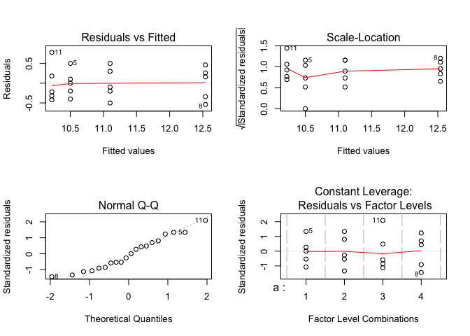

```r
#para que saque los 4 grficos en una pantalla
layout(matrix(c(1,2,3,4),ncol=2))
plot(ejemplo2)
```

Puedo hacer el gráfico 3 por mi misma. Utilizando los resíduos que ya los tengo almacenados

```r
# str(ejemplo2) tenemos los resíduos
```

res = y- val ajustado

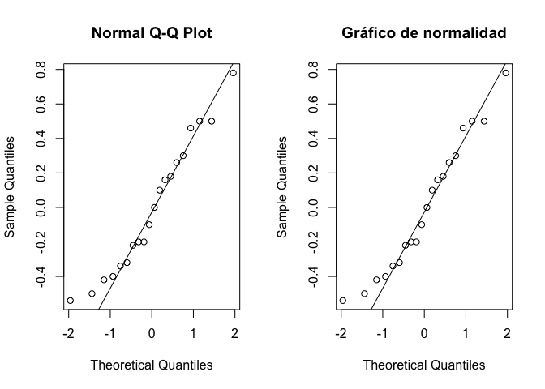

```r
par(mfrow=c(1,2))
qqnorm(ejemplo2$residuals) # grafico qq de normalidad
qqline(ejemplo2$residuals) # grafico qq de normalidad + linea pasando por Q1 y Q3



qqnorm(ejemplo2$residuals,
       main="Gráfico de normalidad" ) # grafico qq de normalidad
qqline(ejemplo2$residuals) # grafico qq de normalidad + linea pasando por Q1 y Q3
```

```r
par(mfrow=c(1,1))
```

Esto es método gráfico. Un método formal es un test de hipótesis.

```r
library(nortest)
#Test de CvM  para contrastar normalidad: hay que cargar el paquete nortest
cvm.test(ejemplo2$residuals) # le quiero aplicar el test a los resíduos
```

```
##
##  Cramer-von Mises normality test
##
## data:  ejemplo2$residuals
## W = 0.052735, p-value = 0.4532
```

Conclusión, por tanto: el p-vlaor es mayor que alfa. No hay evidencias para rechazar la hipótesis nula. $H_0: \epsilon ~ N(0,\sigma^2)$, para algun $\sigma^2>0$.

### Independencia

A modo de ejercicio, en este problema no tiene sentido, porque no sabemos el orden en el que fueron obtenidas las observaciones.

Vamos a suponer que los datos del vector y han sido copiados en el mismo orden que fueron obtenidos los datos

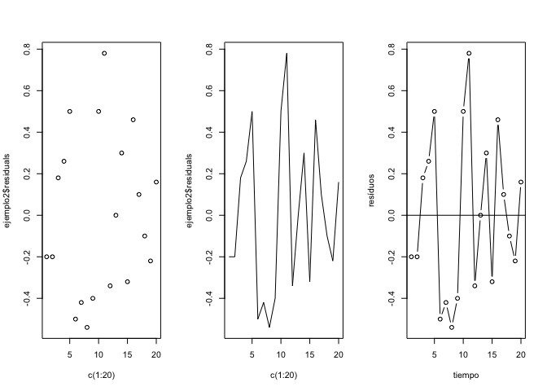

```r
layout(matrix(c(1,2,3),ncol=3))
plot(c(1:20),ejemplo2$residuals, type="p") #dibuja puntos
plot(c(1:20),ejemplo2$residuals, type="l") #dibuja lineas uniendo los puntos
plot(c(1:20),ejemplo2$residuals, type="b", xlab="tiempo", ylab="resíduos") #ambos
abline(h=0) #a\~nade a grafico al linea h=0
```

No se observa patron, podemos decir que existe independencia del tiempo.

### Homocedasteceidad

Gráfico de resíduos frente a medias

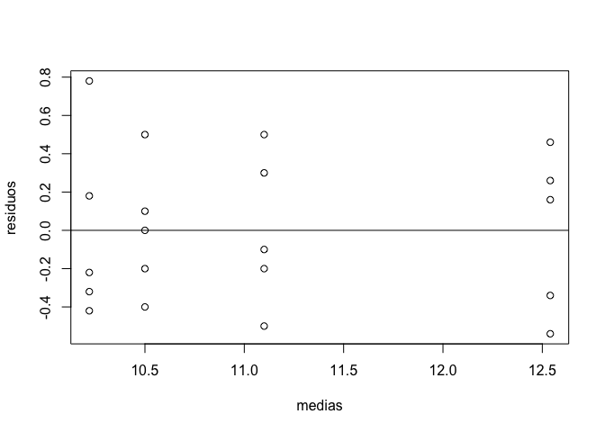

```r
plot(ejemplo2$fitted.values, ejemplo2$residuals, xlab="medias", ylab="residuos")
abline(h=0) #a\~nade a grafico al linea h=0
```

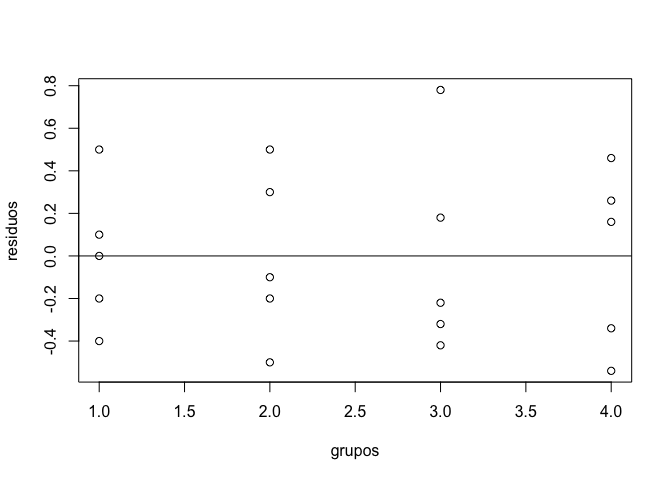

```r
#  residuos vs grupos
#  primero hay que convertir a en numerico, en cc representa el box-plot de cada grupo
a<-as.numeric(a)
plot(a, ejemplo2$residuals, xlab="grupos", ylab="residuos")
abline(h=0) #añade al grafico al linea h=0
```

```r
library(lawstat)
#Test de Levene: hay que cargar el paquete lawstat
levene.test(y,a) # por defecto resta la mediana, en clase lo hicimos con la media y por eso no coincide
```

```
##
##  Modified robust Brown-Forsythe Levene-type test based on the absolute
##  deviations from the median
##
## data:  y
## Test Statistic = 0.10884, p-value = 0.9537
```

Errata en los apuntes, en la página 14, aparece en el test de barlett un 2.pico multiplicando al cociente de la chicuadrado. Ese 2 hay que tacharlo, porque es cuadno el log es en base 10. Nosotros siempre tomamos neperiano, por lo que no necesitamos eso.

```r
#Test de Levene: hay que cargar el paquete lawstat
levene.test(y,a, location = "mean") # por defecto resta la mediana, en clase lo hicimos con la media y por eso no coincide
```

```
##
##  Classical Levene's test based on the absolute deviations from the mean
##  ( none not applied because the location is not set to median )
##
## data:  y
## Test Statistic = 0.4902, p-value = 0.694
```

```r
a<-factor(a)
ares<-abs(ejemplo2$residuals)
summary(aov(ares~a))
```

```
##             Df Sum Sq Mean Sq F value Pr(>F)
## a            3 0.0573 0.01909    0.49  0.694
## Residuals   16 0.6232 0.03895
```

```r
#Test de Bartlett
bartlett.test(y,a)
```

```
##
##  Bartlett test of homogeneity of variances
##
## data:  y and a
## Bartlett's K-squared = 0.50588, df = 3, p-value = 0.9176
```

# Ejercicio 1

Se está realizando un estudio sobre el tiempo de respuesta (medido en milisegundos) de tres tipos diferentes de circuitos que serán utilizados en la construcción de una calculadora. Los resultados son:

```r
y<-c(9,12,10,8,15,
     20,21,23,17,30,
     6,5,8,16,7)
a<-rep(c(1:3),5)
a<-factor(a)
matrix(y,byrow = TRUE,nrow = 3)
```

```
##      [,1] [,2] [,3] [,4] [,5]
## [1,]    9   12   10    8   15
## [2,]   20   21   23   17   30
## [3,]    6    5    8   16    7
```

## Contraste

Realizamos el contraste:

$$\left\{
\begin{array}{ll}
H_{0}: & \alpha_1 = \alpha_2 = \alpha_3 \\
H_{1}: & \alpha_i \neq \alpha_j \quad \text{para algunos } i\neq j
\end{array}
\right.$$

## Tabla ANOVA

```r
ejercicio1<-aov(y~a)
summary(ejercicio1)
```

```
##             Df Sum Sq Mean Sq F value Pr(>F)
## a            2   31.6   15.80   0.265  0.771
## Residuals   12  714.8   59.57
```

# Ejercicio 2

En un laboratorio se estudian cuatro catalizadores que pueden afectar a la concentración de uno de los elementos de una mezcla. Los resultados del estudio se muestran en la siguiente tabla:

```r
y<-c(
        58.2, 57.2,  58.4 , 55.8,54.9,
        56.3 ,54.5 , 57.0 , 55.3,
        50.1, 54.2 , 55.4 ,
        52.9 ,49.9 ,50.0 ,51.7
)

a<-c(rep(1,5),
     rep(2,4),
     rep(3,3),
     rep(4,4))
a<-factor(a)
```

## Estimar los parámetros del modelo

### Tabla anova

```r
ejercicio2<-aov(y~a) # Análisis de la varianza = aov=(respuesta ~ factor)
 # N=15 , k=3
summary(ejercicio2) # tabla de la varianza
```

```
##             Df Sum Sq Mean Sq F value  Pr(>F)
## a            3  85.68   28.56   9.916 0.00144 **
## Residuals   12  34.56    2.88
## ---
## Signif. codes:  0 '***' 0.001 '**' 0.01 '*' 0.05 '.' 0.1 ' ' 1
```

- $\hat\sigma=CM_\epsilon = 2.88$

Para calcular $\hat\alpha$, calculamos el estimador de la media $\hat\mu$

```r
mu.gorro = mean(y)

alpha.gorro = tapply(y, a, mean)- mu.gorro
```

Por tanto, tenemos que $\hat\alpha =$ 2.4125, 1.2875, -1.2541667, -3.3625

La solución que da R es la que se optiene a partir de añadir al sen que $\alpha_1=0$

```r
ejercicio2$coefficients # mu gorro
```

```
## (Intercept)          a2          a3          a4
##   56.900000   -1.125000   -3.666667   -5.775000
```

Esta es la solución que da R, intercept es mu.gorro.

- estimador de alfa1 = 0
- $\hat\alpha_1=0$
- a2 es el estimador de $\alpha_2$, $\hat\alpha_2= -1.125$
- a3 es el estimador de $\alpha3$, $\hat\alpha_3= -3.667$
- a4 es el estimador de $\alpha4$, $\hat\alpha_4= -5.775$

## Diagnosis, ya que existen resultados raritos

A partir de aov se pueden obtener los siguientes 4 gráficos:

### Normalidad

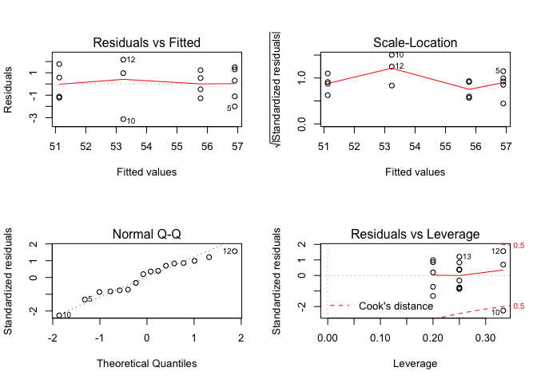

```r
#para que saque los 4 grficos en una pantalla
layout(matrix(c(1,2,3,4),ncol=2))
plot(ejercicio2)
```

Puedo hacer el gráfico 3 por mi misma. Utilizando los resíduos que ya los tengo almacenados

```r
# str(ejemplo2) tenemos los resíduos
```

res = y- val ajustado

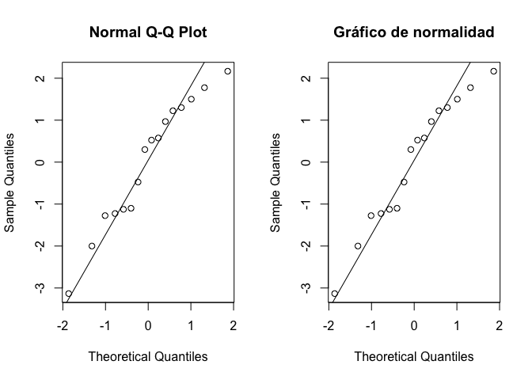

```r
par(mfrow=c(1,2))
qqnorm(ejercicio2$residuals) # grafico qq de normalidad
qqline(ejercicio2$residuals) # grafico qq de normalidad + linea pasando por Q1 y Q3



qqnorm(ejercicio2$residuals,
       main="Gráfico de normalidad" ) # grafico qq de normalidad
qqline(ejercicio2$residuals) # grafico qq de normalidad + linea pasando por Q1 y Q3
```

```r
par(mfrow=c(1,1))
```

Esto es método gráfico. Un método formal es un test de hipótesis.

```r
library(nortest)
#Test de CvM  para contrastar normalidad: hay que cargar el paquete nortest
cvm.test(ejercicio2$residuals) # le quiero aplicar el test a los resíduos
```

```
##
##  Cramer-von Mises normality test
##
## data:  ejercicio2$residuals
## W = 0.063762, p-value = 0.3179
```

Conclusión, por tanto: el p-vlaor es mayor que alfa. No hay evidencias para rechazar la hipótesis nula. $H_0: \epsilon ~ N(0,\sigma^2)$, para algun $\sigma^2>0$.

### Independencia

A modo de ejercicio, en este problema no tiene sentido, porque no sabemos el orden en el que fueron obtenidas las observaciones.

Vamos a suponer que los datos del vector y han sido copiados en el mismo orden que fueron obtenidos los datos

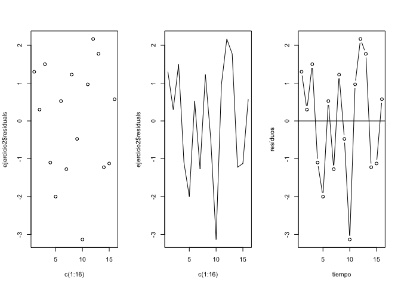

```r
layout(matrix(c(1,2,3),ncol=3))
plot(c(1:16),ejercicio2$residuals, type="p") #dibuja puntos
plot(c(1:16),ejercicio2$residuals, type="l") #dibuja lineas uniendo los puntos
plot(c(1:16),ejercicio2$residuals, type="b", xlab="tiempo", ylab="resíduos") #ambos
abline(h=0) #a\~nade a grafico al linea h=0
```

No se observa patron, podemos decir que existe independencia del nivel de concentración.

### Homocedasteceidad

Gráfico de resíduos frente a medias

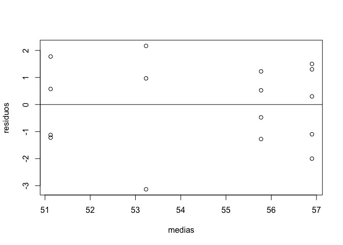

```r
plot(ejercicio2$fitted.values, ejercicio2$residuals, xlab="medias", ylab="residuos")
abline(h=0) #a\~nade a grafico al linea h=0
```

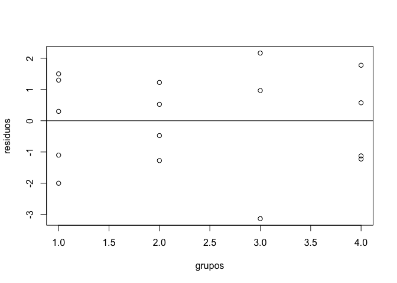

```r
#  residuos vs grupos
#  primero hay que convertir a en numerico, en cc representa el box-plot de cada grupo
a<-as.numeric(a)
plot(a, ejercicio2$residuals, xlab="grupos", ylab="residuos")
abline(h=0) #añade al grafico al linea h=0
```

```r
library(lawstat)
#Test de Levene: hay que cargar el paquete lawstat
levene.test(y,a) # por defecto resta la mediana, en clase lo hicimos con la media y por eso no coincide
```

```
##
##  Modified robust Brown-Forsythe Levene-type test based on the absolute
##  deviations from the median
##
## data:  y
## Test Statistic = 0.42025, p-value = 0.7418
```

- p-valor $= 0.74 > \alpha =0.05$, no rechazo $H_0$, hipótesis de homocedasteceidad.

```r
#Test de Levene: hay que cargar el paquete lawstat
levene.test(y,a, location = "mean") # por defecto resta la mediana, en clase lo hicimos con la media y por eso no coincide
```

```
##
##  Classical Levene's test based on the absolute deviations from the mean
##  ( none not applied because the location is not set to median )
##
## data:  y
## Test Statistic = 2.0537, p-value = 0.1601
```

```r
a<-factor(a)
ares<-abs(ejercicio2$residuals)
summary(aov(ares~a))
```

```
##             Df Sum Sq Mean Sq F value Pr(>F)
## a            3  2.669  0.8896   2.054   0.16
## Residuals   12  5.198  0.4332
```

```r
#Test de Bartlett
bartlett.test(y,a)
```

```
##
##  Bartlett test of homogeneity of variances
##
## data:  y and a
## Bartlett's K-squared = 2.1653, df = 3, p-value = 0.5388
```

## ¿Tienen los cuatro catalizadores el mismo efecto sobre la concentración?

```r
summary(ejercicio2) # tabla de la varianza
```

```
##             Df Sum Sq Mean Sq F value  Pr(>F)
## a            3  85.68   28.56   9.916 0.00144 **
## Residuals   12  34.56    2.88
## ---
## Signif. codes:  0 '***' 0.001 '**' 0.01 '*' 0.05 '.' 0.1 ' ' 1
```

- P-valor = $0.00144 < \alpha = 0.05$, rechazo $H_0$, no tengo evidencias afirmar que los cuatro catalizadores tengan el mismo efecto sobre la concentración.

## Si existiesen diferencias entre los efectos, estudie cuáles pueden ser los motivos de tales diferencias (comparaciones múltiples)

### Test de Tukey

```r
#Test Tukey
#HSD.test(respuesta,factor, gl del error, CM_e)
hsd<-HSD.test(y,a,12,2.88,unbalanced = TRUE)
hsd$groups
```

```
##          y groups
## 1 56.90000      a
## 2 55.77500     ab
## 3 53.23333     bc
## 4 51.12500      c
```

```r
hsd
```

```
## $statistics
##   MSerror Df    Mean       CV
##      2.88 12 54.4875 3.114579
##
## $parameters
##    test name.t ntr StudentizedRange alpha
##   Tukey      a   4          4.19866  0.05
##
## $means
##          y      std r  Min  Max    Q25   Q50    Q75
## 1 56.90000 1.519868 5 54.9 58.4 55.800 57.20 58.200
## 2 55.77500 1.099621 4 54.5 57.0 55.100 55.80 56.475
## 3 53.23333 2.779089 3 50.1 55.4 52.150 54.20 54.800
## 4 51.12500 1.443087 4 49.9 52.9 49.975 50.85 52.000
##
## $comparison
## NULL
##
## $groups
##          y groups
## 1 56.90000      a
## 2 55.77500     ab
## 3 53.23333     bc
## 4 51.12500      c
##
## attr(,"class")
## [1] "group"
```

### Test de Newman-Keuls

```r
#Test Newman-Keuls
#SNK.test(respuesta,factor, gl del error, CM_e)
snk<-SNK.test(y,a,12,2.88)
snk$groups
```

```
##          y groups
## 1 56.90000      a
## 2 55.77500     ab
## 3 53.23333     bc
## 4 51.12500      c
```

```r
snk
```

```
## $statistics
##   MSerror Df    Mean       CV
##      2.88 12 54.4875 3.114579
##
## $parameters
##   test name.t ntr alpha
##    SNK      a   4  0.05
##
## $snk
## NULL
##
## $means
##          y      std r  Min  Max    Q25   Q50    Q75
## 1 56.90000 1.519868 5 54.9 58.4 55.800 57.20 58.200
## 2 55.77500 1.099621 4 54.5 57.0 55.100 55.80 56.475
## 3 53.23333 2.779089 3 50.1 55.4 52.150 54.20 54.800
## 4 51.12500 1.443087 4 49.9 52.9 49.975 50.85 52.000
##
## $comparison
## NULL
##
## $groups
##          y groups
## 1 56.90000      a
## 2 55.77500     ab
## 3 53.23333     bc
## 4 51.12500      c
##
## attr(,"class")
## [1] "group"
```

  ```
    - Concentración de los catalizadores 1 y 2
    - Concentración de los catalizadores 2 y 3
    - Concentración de los catalizadores 4 y 3
  ```

No podemos afirmar que sean significativamente distintas

### Test de Duncan

```r
#Test Duncan
#duncan.test(respuesta,factor, gl del error, CM_e)
duncan<-duncan.test(y,a,12,2.88)
duncan$groups
```

```
##          y groups
## 1 56.90000      a
## 2 55.77500     ab
## 3 53.23333     bc
## 4 51.12500      c
```

Diferencia con el resto: también varía el alfa

```
    - Concentración de los catalizadores 1 y 2
    - Concentración de los catalizadores 2 y 3
    - Concentración de los catalizadores 4 y 3
```

```r
duncan
```

```
## $statistics
##   MSerror Df    Mean       CV
##      2.88 12 54.4875 3.114579
##
## $parameters
##     test name.t ntr alpha
##   Duncan      a   4  0.05
##
## $duncan
## NULL
##
## $means
##          y      std r  Min  Max    Q25   Q50    Q75
## 1 56.90000 1.519868 5 54.9 58.4 55.800 57.20 58.200
## 2 55.77500 1.099621 4 54.5 57.0 55.100 55.80 56.475
## 3 53.23333 2.779089 3 50.1 55.4 52.150 54.20 54.800
## 4 51.12500 1.443087 4 49.9 52.9 49.975 50.85 52.000
##
## $comparison
## NULL
##
## $groups
##          y groups
## 1 56.90000      a
## 2 55.77500     ab
## 3 53.23333     bc
## 4 51.12500      c
##
## attr(,"class")
## [1] "group"
```

Grupo: igual que antes.

### Método de Bonferroni

```r
#Bonferroni
#LSD.test(respuesta,factor, gl del error, CM_e, p.adj="bon")
bon<-LSD.test(y,a,12,2.88,p.adj="bon")
bon
```

```
## $statistics
##   MSerror Df    Mean       CV
##      2.88 12 54.4875 3.114579
##
## $parameters
##         test  p.ajusted name.t ntr alpha
##   Fisher-LSD bonferroni      a   4  0.05
##
## $means
##          y      std r      LCL      UCL  Min  Max    Q25   Q50    Q75
## 1 56.90000 1.519868 5 55.24640 58.55360 54.9 58.4 55.800 57.20 58.200
## 2 55.77500 1.099621 4 53.92622 57.62378 54.5 57.0 55.100 55.80 56.475
## 3 53.23333 2.779089 3 51.09854 55.36813 50.1 55.4 52.150 54.20 54.800
## 4 51.12500 1.443087 4 49.27622 52.97378 49.9 52.9 49.975 50.85 52.000
##
## $comparison
## NULL
##
## $groups
##          y groups
## 1 56.90000      a
## 2 55.77500      a
## 3 53.23333     ab
## 4 51.12500      b
##
## attr(,"class")
## [1] "group"
```

Grupos:

- Catalizadores 1,2,3
- Catalizadores 3 y 4

# Ejercicio 3

```r
y<-c(133.8,125.3,143.1 ,128.9, 135.7 ,
     152.2 ,149.0 ,162.7 ,145.8 ,153.5 ,
      225.8 ,224.6, 220.4 ,212.3 ,
      193.4 ,185.3, 182.8 ,188.5 ,198.6 )
# el diseño no es balanceado
a<-c(rep(1,5),
     rep(2,5),
     rep(3,4),
     rep(4,5))
a<-factor(a)
```

## Tabla anova

```r
Anova3<-aov(y~a)
summary(Anova3)
```

```
##             Df Sum Sq Mean Sq F value   Pr(>F)
## a            3  20423    6808   164.5 1.07e-11 ***
## Residuals   15    621      41
## ---
## Signif. codes:  0 '***' 0.001 '**' 0.01 '*' 0.05 '.' 0.1 ' ' 1
```

## Comparaciones múltiples

```r
hsd <- HSD.test(y,a,15,41,unbalanced = TRUE)
hsd
```

```
## $statistics
##   MSerror Df     Mean       CV
##        41 15 171.6684 3.729937
##
## $parameters
##    test name.t ntr StudentizedRange alpha
##   Tukey      a   4         4.075974  0.05
##
## $means
##         y      std r   Min   Max     Q25   Q50   Q75
## 1 133.360 6.807937 5 125.3 143.1 128.900 133.8 135.7
## 2 152.640 6.367339 5 145.8 162.7 149.000 152.2 153.5
## 3 220.775 6.105940 4 212.3 225.8 218.375 222.5 224.9
## 4 189.720 6.350354 5 182.8 198.6 185.300 188.5 193.4
##
## $comparison
## NULL
##
## $groups
##         y groups
## 3 220.775      a
## 4 189.720      b
## 2 152.640      c
## 1 133.360      d
##
## attr(,"class")
## [1] "group"
```

Rechazo porque hay 4 grupos distintos, las 4 dietas son diferentes.

### Test de Tukey

```r
#Test Tukey
#HSD.test(respuesta,factor, gl del error, CM_e)
hsd<-HSD.test(y,a,15,41,unbalanced = TRUE)
hsd$groups
```

```
##         y groups
## 3 220.775      a
## 4 189.720      b
## 2 152.640      c
## 1 133.360      d
```

## Diagnosis

### Normalidad

#### Gráfico

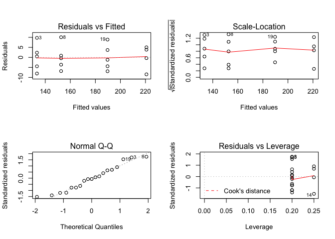

```r
layout(matrix(c(1,2,3,4),ncol=2))
plot(Anova3)
```

Gráficamente observando el QQ plot parece que voy a aceptar la normalidad, los puntos están alrededor de una linea recta, con más enfasis en el centro existen oscilaciones en los extremos

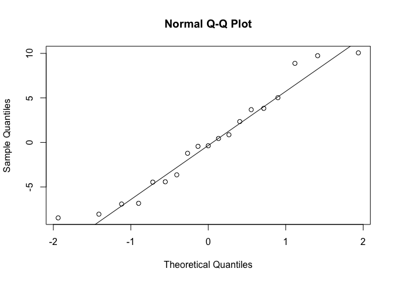

```r
qqnorm(Anova3$residuals) # grafico qq de normalidad
qqline(Anova3$residuals) # grafico qq de normalidad + linea pasando por Q1 y Q3
```

#### Test de CvM para contrastar normalidad

Test: H0: $\epsilon \sim N(0,\sigma^2), \quad \text{con } \sigma^2 > 0$

```r
cvm.test(Anova3$residuals)
```

```
##
##  Cramer-von Mises normality test
##
## data:  Anova3$residuals
## W = 0.031706, p-value = 0.8108
```

No existen evidencias para decir que los errores no se distribuyen segun una ley normal

### Independencia

No tiene sentido aquí, ya que no puedo saber cuadno he observado las respuestas

### Homocedasteceidad

#### Método gráfico

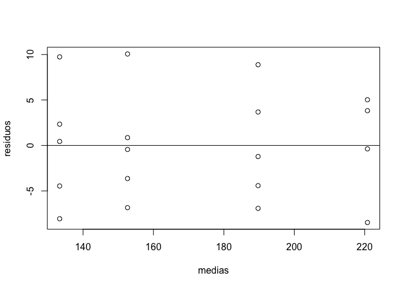

```r
# residuos vs valores ajustados
plot(Anova3$fitted.values, Anova3$residuals, xlab="medias", ylab="residuos")
abline(h=0) #añade a grafico al linea h=0
```

Datos en torno a una banda, no se observa que la oscilación cambie con el valor de los fitted values, parece por el gráfico que no voy a rechazar la homocedasteceidad el gráfico me ayuda a saber el porque rechazo

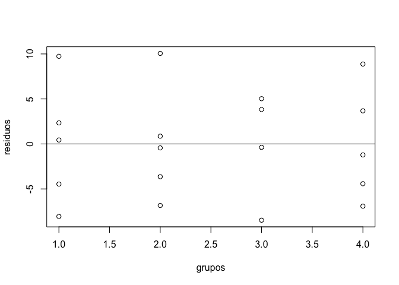

```r
#  residuos vs grupos
a<-as.numeric(a)
plot(a, Anova3$residuals, xlab="grupos", ylab="residuos")
abline(h=0) #añade al grafico al linea h=0
```

#### Test

```r
#Test de Levene: hay que cargar el paquete lawstat
library(lawstat)
levene.test(y,a,location = "mean") # deviations from the median
```

```
##
##  Classical Levene's test based on the absolute deviations from the mean
##  ( none not applied because the location is not set to median )
##
## data:  y
## Test Statistic = 0.047196, p-value = 0.9859
```

```r
# Nota: si hay outliers el p-valor habría cambiado considerablemente al poner mean
```

No existen evidencias en contra de la hipótesis homocedastecerdad, por tanto, las varianzas son iguales.

```r
#Test de Bartlett
bartlett.test(y,a)
```

```
##
##  Bartlett test of homogeneity of variances
##
## data:  y and a
## Bartlett's K-squared = 0.040086, df = 3, p-value = 0.9979
```

Misma conclusión con este test

# Ejercicio 4

## Contraste

```r
y<-c(
     7 ,7  ,15 ,11, 9,
     12,17 ,12 ,18, 18 ,
     14,18 ,19 ,19,  19,
     19,25 ,22 ,19, 23 ,
     7 ,10 ,11 ,15, 11
)
a<-c(rep(1,5),rep(2,5),rep(3,5),rep(4,5),rep(5,5))
a<-factor(a)
```

Realizamos el contraste:

## Tabla ANOVA

```r
ejercicio4<-aov(y~a)
summary(ejercicio4)
```

```
##             Df Sum Sq Mean Sq F value   Pr(>F)
## a            4  481.0  120.26   14.77 9.05e-06 ***
## Residuals   20  162.8    8.14
## ---
## Signif. codes:  0 '***' 0.001 '**' 0.01 '*' 0.05 '.' 0.1 ' ' 1
```

- k=5
- N=25
- gr lib k-1 = 4
- gr lib resíduos, gr lib del error N-k = 20
- p-valor enano, no tengo evidencias significativas para afirmar que la resistencia media de los tejidos es la misma.

## Comparaciones múltiples

### Test de Tukey

```r
#Test Tukey
#HSD.test(respuesta,factor, gl del error, CM_e)
hsd<-HSD.test(y,a,20,8.14)
hsd$groups
```

```
##      y groups
## 4 21.6      a
## 3 17.8     ab
## 2 15.4     bc
## 5 10.8     cd
## 1  9.8      d
```

```r
hsd
```

```
## $statistics
##   MSerror Df  Mean       CV      MSD
##      8.14 20 15.08 18.91955 5.399557
##
## $parameters
##    test name.t ntr StudentizedRange alpha
##   Tukey      a   5         4.231857  0.05
##
## $means
##      y      std r Min Max Q25 Q50 Q75
## 1  9.8 3.346640 5   7  15   7   9  11
## 2 15.4 3.130495 5  12  18  12  17  18
## 3 17.8 2.167948 5  14  19  18  19  19
## 4 21.6 2.607681 5  19  25  19  22  23
## 5 10.8 2.863564 5   7  15  10  11  11
##
## $comparison
## NULL
##
## $groups
##      y groups
## 4 21.6      a
## 3 17.8     ab
## 2 15.4     bc
## 5 10.8     cd
## 1  9.8      d
##
## attr(,"class")
## [1] "group"
```

- StudentizedRange: Punto crítico del recorrido studentizado = 4.23
- MSD es el hsd = 5.399

Grupos:

- Tejido 4 y 3
- Tejido 3 y 2
- Tejido 2 y 5
- Tejido 5 y 1

Para el desempate: teste de N-K

### Test de Newman-Keuls

```r
#Test Newman-Keuls
#SNK.test(respuesta,factor, gl del error, CM_e)
snk<-SNK.test(y,a,20,8.14)
snk$groups
```

```
##      y groups
## 4 21.6      a
## 3 17.8      b
## 2 15.4      b
## 5 10.8      c
## 1  9.8      c
```

Conclusión: tengo tres grupos de tejidos con resistencia significativamente similar

- Tejido 4
- Tejidos 3 y 2
- Tejidos 5 y 1

```r
snk
```

```
## $statistics
##   MSerror Df  Mean       CV
##      8.14 20 15.08 18.91955
##
## $parameters
##   test name.t ntr alpha
##    SNK      a   5  0.05
##
## $snk
##      Table CriticalRange
## 2 2.949998      3.763994
## 3 3.577935      4.565198
## 4 3.958293      5.050509
## 5 4.231857      5.399557
##
## $means
##      y      std r Min Max Q25 Q50 Q75
## 1  9.8 3.346640 5   7  15   7   9  11
## 2 15.4 3.130495 5  12  18  12  17  18
## 3 17.8 2.167948 5  14  19  18  19  19
## 4 21.6 2.607681 5  19  25  19  22  23
## 5 10.8 2.863564 5   7  15  10  11  11
##
## $comparison
## NULL
##
## $groups
##      y groups
## 4 21.6      a
## 3 17.8      b
## 2 15.4      b
## 5 10.8      c
## 1  9.8      c
##
## attr(,"class")
## [1] "group"
```

Nota: Por tanto, hemos rechazado porque existen tres grupos diferentes de resistencia de tejidos.

## Diagnosis

A partir de aov se pueden obtener los siguientes 4 gráficos:

### Normalidad

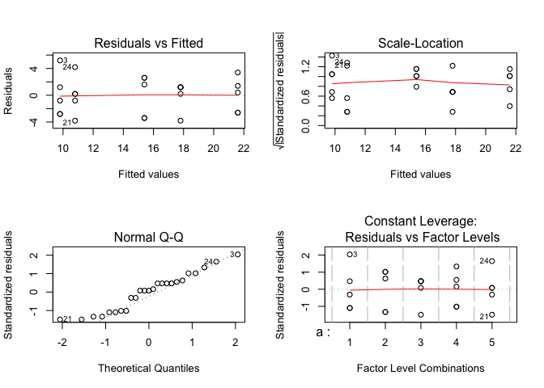

```r
#para que saque los 4 grficos en una pantalla
layout(matrix(c(1,2,3,4),ncol=2))
plot(ejercicio4)
```

Puedo hacer el gráfico 3 por mi misma. Utilizando los resíduos que ya los tengo almacenados

```r
# str(ejemplo2) tenemos los resíduos
```

res = y- val ajustado

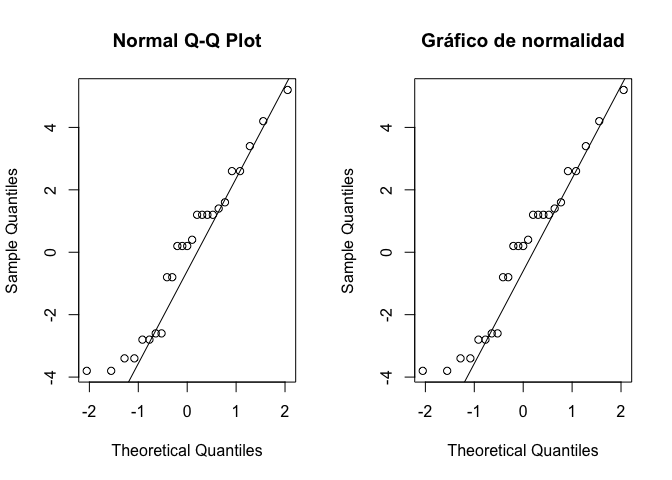

```r
par(mfrow=c(1,2))
qqnorm(ejercicio4$residuals) # grafico qq de normalidad
qqline(ejercicio4$residuals) # grafico qq de normalidad + linea pasando por Q1 y Q3



qqnorm(ejercicio4$residuals,
       main="Gráfico de normalidad" ) # grafico qq de normalidad
qqline(ejercicio4$residuals) # grafico qq de normalidad + linea pasando por Q1 y Q3
```

```r
par(mfrow=c(1,1))
```

Esto es método gráfico. Un método formal es un test de hipótesis.

```r
library(nortest)
#Test de CvM  para contrastar normalidad: hay que cargar el paquete nortest
cvm.test(ejercicio4$residuals) # le quiero aplicar el test a los resíduos
```

```
##
##  Cramer-von Mises normality test
##
## data:  ejercicio4$residuals
## W = 0.084303, p-value = 0.1734
```

Conclusión, por tanto: el p-valor es mayor que alfa. No hay evidencias para rechazar la hipótesis nula. $H_0: \epsilon ~ N(0,\sigma^2)$, para algun $\sigma^2>0$.

### Independencia

A modo de ejercicio, en este problema no tiene sentido, porque no sabemos el orden en el que fueron obtenidas las observaciones.

Vamos a suponer que los datos del vector y han sido copiados en el mismo orden que fueron obtenidos los datos

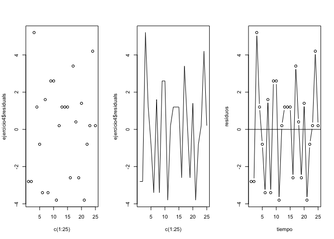

```r
layout(matrix(c(1,2,3),ncol=3))
plot(c(1:25),ejercicio4$residuals, type="p") #dibuja puntos
plot(c(1:25),ejercicio4$residuals, type="l") #dibuja lineas uniendo los puntos
plot(c(1:25),ejercicio4$residuals, type="b", xlab="tiempo", ylab="resíduos") #ambos
abline(h=0) #a\~nade a grafico al linea h=0
```

No se observa patron, podemos decir que existe independencia del tiempo.

### Homocedasteceidad

Gráfico de resíduos frente a medias

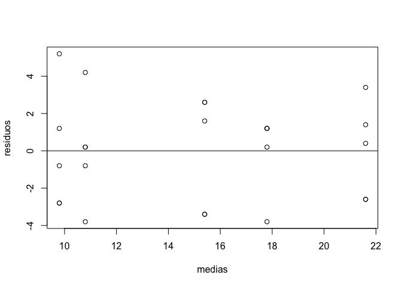

```r
plot(ejercicio4$fitted.values, ejercicio4$residuals, xlab="medias", ylab="residuos")
abline(h=0) #a\~nade a grafico al linea h=0
```

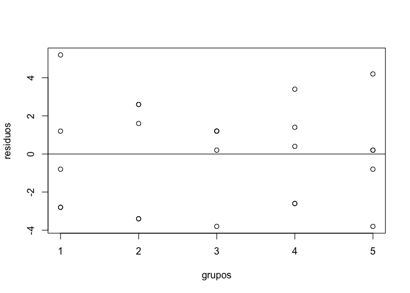

```r
#  residuos vs grupos
#  primero hay que convertir a en numerico, en cc representa el box-plot de cada grupo
a<-as.numeric(a)
plot(a, ejercicio4$residuals, xlab="grupos", ylab="residuos")
abline(h=0) #añade al grafico al linea h=0
```

```r
library(lawstat)
#Test de Levene: hay que cargar el paquete lawstat
levene.test(y,a) # por defecto resta la mediana, en clase lo hicimos con la media y por eso no coincide
```

```
##
##  Modified robust Brown-Forsythe Levene-type test based on the absolute
##  deviations from the median
##
## data:  y
## Test Statistic = 0.28837, p-value = 0.882
```

P-valor mayor que alpha, no existen evidencias en contra de la hipótesis de homocedasteceidad

Errata en los apuntes, en la página 14, aparece en el test de barlett un 2.pico multiplicando al cociente de la chicuadrado. Ese 2 hay que tacharlo, porque es cuadno el log es en base 10. Nosotros siempre tomamos neperiano, por lo que no necesitamos eso.

```r
#Test de Levene: hay que cargar el paquete lawstat
levene.test(y,a, location = "mean") # por defecto resta la mediana, en clase lo hicimos con la media y por eso no coincide
```

```
##
##  Classical Levene's test based on the absolute deviations from the mean
##  ( none not applied because the location is not set to median )
##
## data:  y
## Test Statistic = 0.57697, p-value = 0.6826
```

```r
a<-factor(a)
ares<-abs(ejercicio4$residuals)
summary(aov(ares~a))
```

```
##             Df Sum Sq Mean Sq F value Pr(>F)
## a            4   4.95   1.238   0.577  0.683
## Residuals   20  42.93   2.146
```

```r
#Test de Bartlett
bartlett.test(y,a)
```

```
##
##  Bartlett test of homogeneity of variances
##
## data:  y and a
## Bartlett's K-squared = 0.78922, df = 4, p-value = 0.9399
```

# Ejercicio 5

Los datos han sido obtenidos bajo cuatro condiciones, se desea averiguar si las condiciones consideradas inciden en la respuesta media.

## Contraste

```r
y<-c(39 ,40 ,42 ,37 ,40 ,40 ,38 ,39 ,41 ,38,
 34 ,34 ,34 ,34 ,35 ,35 ,34 ,35 ,34 ,34,
 41 ,39 ,41 ,41 ,41 ,40 ,40 ,41 ,41 ,41,
 37 ,37 ,36 ,36 ,38 ,37 ,39 ,36 ,36 ,38)



a<-c(rep(1,10),rep(2,10),rep(3,10),rep(4,10))
a<-factor(a)
```

Realizamos el contraste:

$$\left\{
\begin{array}{ll}
H_{0}: & \alpha_1 = \alpha_2 = \alpha_3 = \alpha_4\\
H_{1}: & \alpha_i \neq \alpha_j \quad \text{para algunos } i\neq j
\end{array}
\right.$$

## Tabla ANOVA

```r
ejercicio5<-aov(y~a)
summary(ejercicio5)
```

```
##             Df Sum Sq Mean Sq F value   Pr(>F)
## a            3  232.9   77.63   75.73 1.28e-15 ***
## Residuals   36   36.9    1.02
## ---
## Signif. codes:  0 '***' 0.001 '**' 0.01 '*' 0.05 '.' 0.1 ' ' 1
```

## Comparaciones múltiples

### Test de Tukey

```r
#Test Tukey
#HSD.test(respuesta,factor, gl del error, CM_e)
hsd<-HSD.test(y,a,36,1.02)
hsd$groups
```

```
##      y groups
## 3 40.6      a
## 1 39.4      a
## 4 37.0      b
## 2 34.3      c
```

```r
hsd
```

```
## $statistics
##   MSerror Df   Mean       CV      MSD
##      1.02 36 37.825 2.670061 1.216433
##
## $parameters
##    test name.t ntr StudentizedRange alpha
##   Tukey      a   4         3.808798  0.05
##
## $means
##      y       std  r Min Max   Q25  Q50   Q75
## 1 39.4 1.5055453 10  37  42 38.25 39.5 40.00
## 2 34.3 0.4830459 10  34  35 34.00 34.0 34.75
## 3 40.6 0.6992059 10  39  41 40.25 41.0 41.00
## 4 37.0 1.0540926 10  36  39 36.00 37.0 37.75
##
## $comparison
## NULL
##
## $groups
##      y groups
## 3 40.6      a
## 1 39.4      a
## 4 37.0      b
## 2 34.3      c
##
## attr(,"class")
## [1] "group"
```

- StudentizedRange: Punto crítico del recorrido studentizado = 3.808798
- MSD es el hsd = 1.21

Grupos:

- Condición 3 y 1
- Condición 4
- Condición 2

Para el desempate: teste de N-K

### Test de Newman-Keuls

```r
#Test Newman-Keuls
#SNK.test(respuesta,factor, gl del error, CM_e)
snk<-SNK.test(y,a,36,1.02)
snk$groups
```

```
##      y groups
## 3 40.6      a
## 1 39.4      b
## 4 37.0      c
## 2 34.3      d
```

Conclusión: tengo cuatro grupo de condiciones diferentes con respuesta media diferente

```r
snk
```

```
## $statistics
##   MSerror Df   Mean       CV
##      1.02 36 37.825 2.670061
##
## $parameters
##   test name.t ntr alpha
##    SNK      a   4  0.05
##
## $snk
##      Table CriticalRange
## 2 2.868158     0.9160162
## 3 3.456758     1.1040000
## 4 3.808798     1.2164327
##
## $means
##      y       std  r Min Max   Q25  Q50   Q75
## 1 39.4 1.5055453 10  37  42 38.25 39.5 40.00
## 2 34.3 0.4830459 10  34  35 34.00 34.0 34.75
## 3 40.6 0.6992059 10  39  41 40.25 41.0 41.00
## 4 37.0 1.0540926 10  36  39 36.00 37.0 37.75
##
## $comparison
## NULL
##
## $groups
##      y groups
## 3 40.6      a
## 1 39.4      b
## 4 37.0      c
## 2 34.3      d
##
## attr(,"class")
## [1] "group"
```

## Diagnosis

A partir de aov se pueden obtener los siguientes 4 gráficos:

### Normalidad

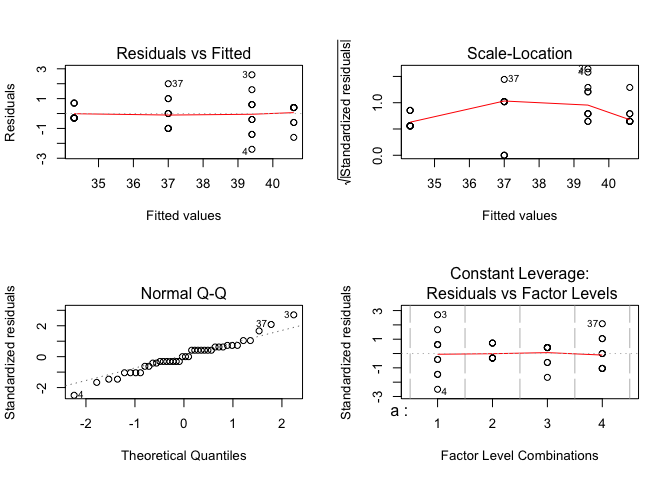

```r
#para que saque los 4 grficos en una pantalla
layout(matrix(c(1,2,3,4),ncol=2))
plot(ejercicio5)
```

Puedo hacer el gráfico 3 por mi misma. Utilizando los resíduos que ya los tengo almacenados

```r
# str(ejemplo2) tenemos los resíduos
```

res = y- val ajustado

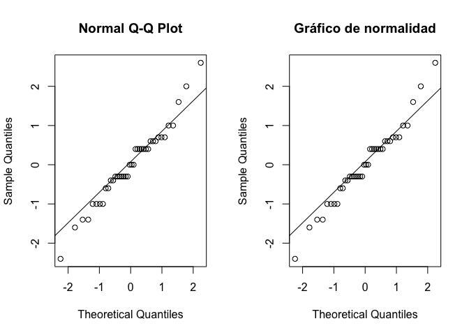

```r
par(mfrow=c(1,2))
qqnorm(ejercicio5$residuals) # grafico qq de normalidad
qqline(ejercicio5$residuals) # grafico qq de normalidad + linea pasando por Q1 y Q3



qqnorm(ejercicio5$residuals,
       main="Gráfico de normalidad" ) # grafico qq de normalidad
qqline(ejercicio5$residuals) # grafico qq de normalidad + linea pasando por Q1 y Q3
```

```r
par(mfrow=c(1,1))
```

Esto es método gráfico. Un método formal es un test de hipótesis.

```r
#Test de CvM  para contrastar normalidad: hay que cargar el paquete nortest
cvm.test(ejercicio5$residuals) # le quiero aplicar el test a los resíduos
```

```
##
##  Cramer-von Mises normality test
##
## data:  ejercicio5$residuals
## W = 0.087194, p-value = 0.1619
```

Conclusión, por tanto: el p-valor es mayor que alfa. No hay evidencias para rechazar la hipótesis nula. $H_0: \epsilon ~ N(0,\sigma^2)$, para algún $\sigma^2>0$.

### Independencia

A modo de ejercicio, en este problema no tiene sentido, porque no sabemos el orden en el que fueron obtenidas las observaciones.

Vamos a suponer que los datos del vector y han sido copiados en el mismo orden que fueron obtenidos los datos

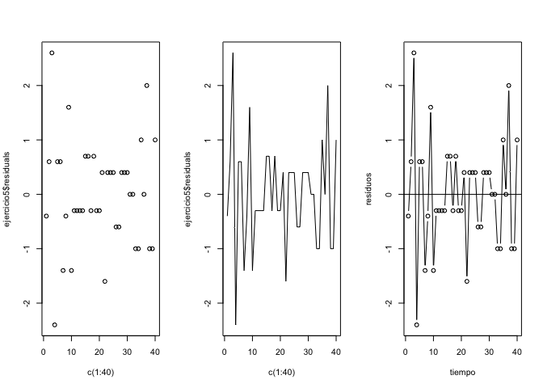

```r
layout(matrix(c(1,2,3),ncol=3))
plot(c(1:40),ejercicio5$residuals, type="p") #dibuja puntos
plot(c(1:40),ejercicio5$residuals, type="l") #dibuja lineas uniendo los puntos
plot(c(1:40),ejercicio5$residuals, type="b", xlab="tiempo", ylab="resíduos") #ambos
abline(h=0) #a\~nade a grafico al linea h=0
```

No se observa patron, podemos decir que existe independencia del tiempo.

### Homocedasteceidad

Gráfico de resíduos frente a medias

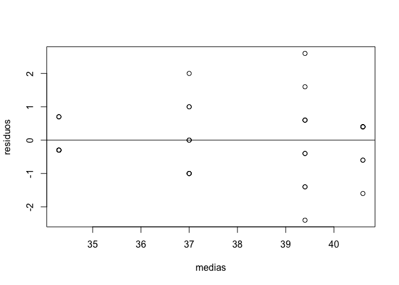

```r
plot(ejercicio5$fitted.values, ejercicio5$residuals, xlab="medias", ylab="residuos")
abline(h=0) #a\~nade a grafico al linea h=0
```

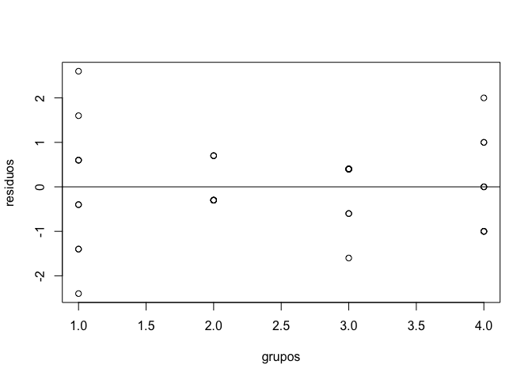

```r
#  residuos vs grupos
#  primero hay que convertir a en numerico, en cc representa el box-plot de cada grupo
a<-as.numeric(a)
plot(a, ejercicio5$residuals, xlab="grupos", ylab="residuos")
abline(h=0) #añade al grafico al linea h=0
```

```r
#Test de Levene: hay que cargar el paquete lawstat
levene.test(y,a) # por defecto resta la mediana, en clase lo hicimos con la media y por eso no coincide
```

```
##
##  Modified robust Brown-Forsythe Levene-type test based on the absolute
##  deviations from the median
##
## data:  y
## Test Statistic = 3.7593, p-value = 0.01906
```

P-valor menor que alpha, no existen evidencias a favor de la hipótesis de homocedasteceidad.

```r
#Test de Levene: hay que cargar el paquete lawstat
levene.test(y,a, location = "mean") # por defecto resta la mediana, en clase lo hicimos con la media y por eso no coincide
```

```
##
##  Classical Levene's test based on the absolute deviations from the mean
##  ( none not applied because the location is not set to median )
##
## data:  y
## Test Statistic = 3.7489, p-value = 0.01927
```

```r
a<-factor(a)
ares<-abs(ejercicio5$residuals)
summary(aov(ares~a))
```

```
##             Df Sum Sq Mean Sq F value Pr(>F)
## a            3  3.499  1.1663   3.749 0.0193 *
## Residuals   36 11.200  0.3111
## ---
## Signif. codes:  0 '***' 0.001 '**' 0.01 '*' 0.05 '.' 0.1 ' ' 1
```

```r
#Test de Bartlett
bartlett.test(y,a)
```

```
##
##  Bartlett test of homogeneity of variances
##
## data:  y and a
## Bartlett's K-squared = 11.578, df = 3, p-value = 0.008978
```

No existe homocedasteceidad.